# Assessment 3

MENG CHEN 4652515

11/09/2021

# BCO7000 Assessment 3

## “MENG CHEN 4652515”“Ke Ni 4660593”

# ABOUT THE DATASET [Historical Phone Usage]

### The dataset demonstrate the adoption of mobile phones by country.And explores how different contitent affect the subscription of mobile and landline. The GDP per capita of a country probably affects the adoption of mobile phones.

## Load the dataset

```r
library(tidyverse)
library(knitr)
library(tidymodels)
library(ranger)
mobile <- readr::read_csv('https://raw.githubusercontent.com/rfordatascience/tidytuesday/master/data/2020/2020-11-10/mobile.csv')
landline <- readr::read_csv('https://raw.githubusercontent.com/rfordatascience/tidytuesday/master/data/2020/2020-11-10/landline.csv')
```

# QUESTIONS

### We know the fixed mobile and telephone subscriptions, and GDP per capita and the continent.

*Major Question: How can we predict and increase sales using the continent and GDP?*

*Subquestions:*

Q1. Which characteristics predict the usage of mobile and telephone?

Q2. What is the relation between the GDP per capita and the subscription?

Q3. Is the relation between the GDP per capita and subscription dependent on contient?

# EXPLORATORY ANALYSIS

## Q1. Which characteristics predict the usage of mobile and telephone?

```r
mobile <- mobile %>%
  mutate_if(is.character, factor)

landline <- landline %>%
  mutate_if(is.character, factor)

mobile%>%
  count(continent)%>%
  arrange()%>%
  kable()
```

| continent | n |
| --- | --- |
| Africa | 1611 |
| Americas | 1319 |
| Asia | 1422 |
| Europe | 1330 |
| Oceania | 595 |

```r
landline%>%
  count(continent)%>%
  arrange()%>%
  kable()
```

| continent | n |
| --- | --- |
| Africa | 1741 |
| Americas | 1622 |
| Asia | 1531 |
| Europe | 1417 |
| Oceania | 663 |

## Q2. What is the relation between the GDP per capita and the subscription?

### To find this relation, let’s plot the gdp_per_cap as X-axis and subscription as Y-axis. We then use the linear regression to see how they are related.

### For mobiles

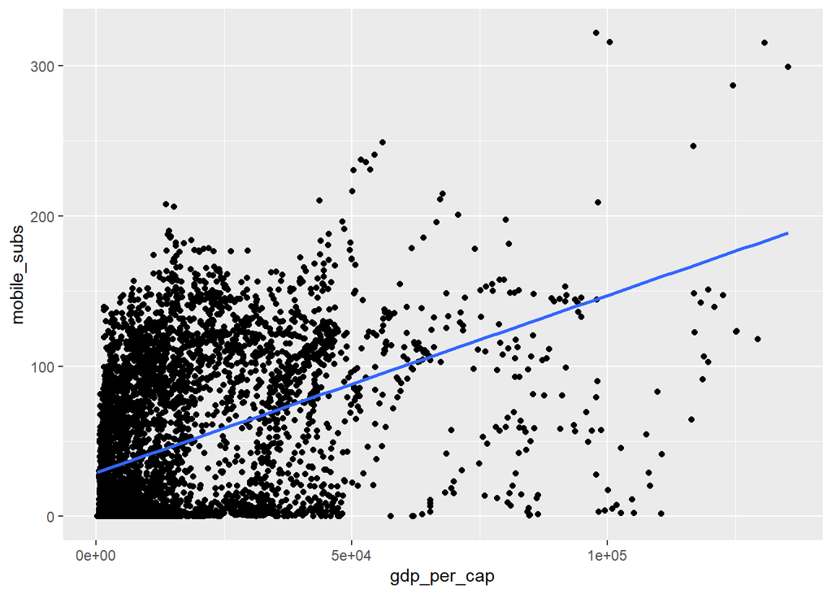

```r
mobile%>%
  filter(mobile_subs!="None",gdp_per_cap!="None")%>%
  ggplot(aes(gdp_per_cap,mobile_subs)) +
  geom_point() +
  geom_smooth(method = lm, se = FALSE)
```

### For landline

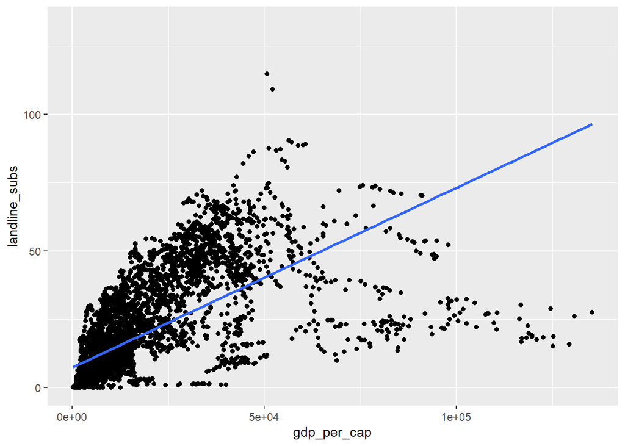

```r
landline%>%
  ggplot(aes(gdp_per_cap,landline_subs)) +
  geom_point() +
  geom_smooth(method = lm, se = FALSE)
```

## *We can see that urchins that when GDP per capita is higher, the subscriptions is more as well.The slope of the line shows a positive relation between the GDP per capita and the subscriptions.*

## Q3. Is the relation between the GDP per capita and subscription dependent on contient?

### Now, let’s see if the above identified positive relation is dependent on the different continent.

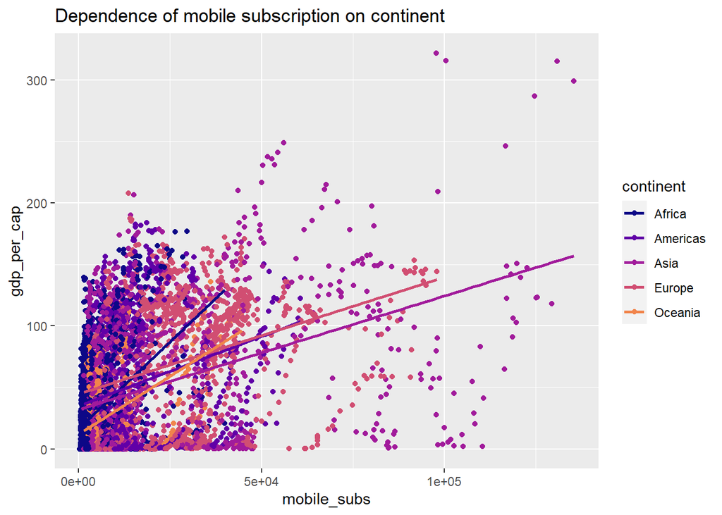

```r
mobile %>%
  ggplot(aes(gdp_per_cap, mobile_subs,colour = continent)) +
  geom_point() +
  geom_smooth(method = lm, se = FALSE) +
  scale_color_viridis_d(option = "plasma", end = .7)+
  labs(x = "mobile_subs", y = "gdp_per_cap", colour = "continent", title = "Dependence of mobile subscription on continent")
```

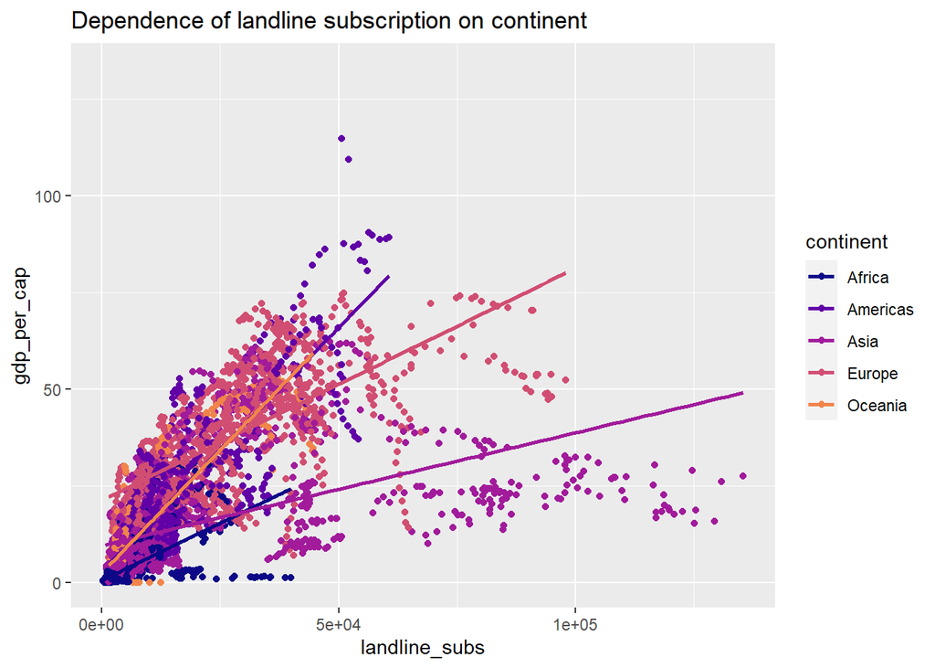

```r
  landline %>%
  ggplot(aes(gdp_per_cap,landline_subs,  colour = continent)) +
  geom_point() +
  geom_smooth(method = lm, se = FALSE) +
  scale_color_viridis_d(option = "plasma", end = .7)+
  labs(x = "landline_subs", y = "gdp_per_cap", colour = "continent", title = "Dependence of landline subscription on continent")
```

## *We can see that all the slopes shows a positive relation. However, these slopes look different. For mobile subscription, the subscription of Africa is higher than other continents when the GDP is same.For landline, the subscription of America and oceania is higher than other continents when the GDP is same.*

# PREDICTIVE ANALYSIS

### Step 1: Split the dataset into Training & Testing datasets.

```r
mobile_split <- initial_split(mobile)
mobile_train <- training(mobile_split)
mobile_test <- testing(mobile_split)

landline_split <- initial_split(landline)
landline_train <- training(landline_split)
landline_test <- testing(landline_split)
```

### Step 2: Pre-process the data.

### on this modelling, we will use 3 variables from the dataset.

### *Since we are predicting the mobile and landline subscription of the urchins, subscription is our Output variable and the others are our Input variables or Predictors.*

```r
mobile_recipe <- recipe(mobile_subs ~ gdp_per_cap+continent , data = mobile_train)

summary(mobile_recipe)
```

```
## # A tibble: 3 x 4
##   variable    type    role      source
##   <chr>       <chr>   <chr>     <chr>
## 1 gdp_per_cap numeric predictor original
## 2 continent   nominal predictor original
## 3 mobile_subs numeric outcome   original
```

```r
mobile_recipe <- mobile_recipe %>%
  step_center(all_numeric(), -all_outcomes()) %>%
  step_scale(all_numeric(), -all_outcomes()) %>%
  step_corr(all_numeric())

mobile_prep <- prep(mobile_recipe, training = mobile_train)

mobile_bake <- bake(mobile_prep, mobile_train)

mobile_bake
```

```
## # A tibble: 4,707 x 3
##    gdp_per_cap continent mobile_subs
##          <dbl> <fct>           <dbl>
##  1       0.964 Africa         42.0
##  2       1.07  Europe         28.8
##  3      -0.771 Africa          0
##  4      -0.764 Africa         36.5
##  5      -0.185 Asia           60.2
##  6       0.819 Europe          0.670
##  7      -0.416 Oceania        64.9
##  8      NA     Europe         NA
##  9      -0.659 Africa         79.9
## 10      -0.590 Africa         32.4
## # ... with 4,697 more rows
```

```r
landline_recipe <- recipe(landline_subs ~ gdp_per_cap+continent , data = landline_train)

summary(landline_recipe)
```

```
## # A tibble: 3 x 4
##   variable      type    role      source
##   <chr>         <chr>   <chr>     <chr>
## 1 gdp_per_cap   numeric predictor original
## 2 continent     nominal predictor original
## 3 landline_subs numeric outcome   original
```

```r
landline_recipe <- landline_recipe %>%
  step_center(all_numeric(), -all_outcomes()) %>%
  step_scale(all_numeric(), -all_outcomes()) %>%
  step_corr(all_numeric())

landline_prep <- prep(landline_recipe, training = landline_train)

landline_bake <- bake(landline_prep, landline_train)

landline_bake
```

```
## # A tibble: 5,230 x 3
##    gdp_per_cap continent landline_subs
##          <dbl> <fct>             <dbl>
##  1      -0.291 Americas         21.1
##  2      -0.604 Asia              4.73
##  3      -0.548 Asia              2.09
##  4      NA     Oceania          13.1
##  5      NA     Americas         NA
##  6      -0.589 Asia              0.588
##  7       0.836 Europe           40.4
##  8      NA     Europe           NA
##  9      -0.409 Africa            7.33
## 10       0.163 Africa           30.2
## # ... with 5,220 more rows
```

### Step 3: Build a model

```r
model_mobile <- linear_reg() %>%
  set_mode("regression") %>%
  set_engine("lm")

model_mobile
```

```
## Linear Regression Model Specification (regression)
##
## Computational engine: lm
```

```r
model_mobile_fitted <- model_mobile %>%
  fit(mobile_subs ~ gdp_per_cap*continent, data = mobile_bake)

summary(model_mobile_fitted)
```

```
##         Length Class      Mode
## lvl      0     -none-     NULL
## spec     5     linear_reg list
## fit     14     lm         list
## preproc  1     -none-     list
## elapsed  5     proc_time  numeric
```

```r
model_landline <- linear_reg() %>%
  set_mode("regression") %>%
  set_engine("lm")


model_landline
```

```
## Linear Regression Model Specification (regression)
##
## Computational engine: lm
```

```r
model_landline_fitted <- model_landline %>%
  fit(landline_subs ~ gdp_per_cap*continent, data = landline_bake)

summary(model_landline_fitted)
```

```
##         Length Class      Mode
## lvl      0     -none-     NULL
## spec     5     linear_reg list
## fit     14     lm         list
## preproc  1     -none-     list
## elapsed  5     proc_time  numeric
```

### Step 4: Create a workflow

### We then create a workflow to save the recipe and the model together. This workflow can then be used in future with any new data.Thus if we know the continent and GDP, we can predict the usage of mobile and landline.

```r
workflow_mobile <- workflow() %>%
  add_recipe(mobile_recipe) %>%
  add_model(model_mobile)

workflow_mobile
```

```
## == Workflow ====================================================================
## Preprocessor: Recipe
## Model: linear_reg()
##
## -- Preprocessor ----------------------------------------------------------------
## 3 Recipe Steps
##
## * step_center()
## * step_scale()
## * step_corr()
##
## -- Model -----------------------------------------------------------------------
## Linear Regression Model Specification (regression)
##
## Computational engine: lm
```

```r
workflow_landline <- workflow() %>%
  add_recipe(landline_recipe) %>%
  add_model(model_landline)

workflow_landline
```

```
## == Workflow ====================================================================
## Preprocessor: Recipe
## Model: linear_reg()
##
## -- Preprocessor ----------------------------------------------------------------
## 3 Recipe Steps
##
## * step_center()
## * step_scale()
## * step_corr()
##
## -- Model -----------------------------------------------------------------------
## Linear Regression Model Specification (regression)
##
## Computational engine: lm
```